# Забродина Дарья

# Визуализация

## Suicide Rates Overview 1985 to 2016

```python
import pandas as pd

from sklearn.preprocessing import OneHotEncoder
import numpy as np
import datetime
import matplotlib.pyplot as plt
import seaborn as sns
%matplotlib inline
import matplotlib.ticker as ticker
```

```python
data = pd.read_csv('master.csv')
```

```python
data.head(10)
```

|  | country | year | sex | age | suicides_no | population | suicides/100k pop | country-year | HDI for year | gdp_for_year ($) | gdp_per_capita ($) | generation |
| --- | --- | --- | --- | --- | --- | --- | --- | --- | --- | --- | --- | --- |
| 0 | Albania | 1987 | male | 15-24 years | 21 | 312900 | 6.71 | Albania1987 | NaN | 2,156,624,900 | 796 | Generation X |
| 1 | Albania | 1987 | male | 35-54 years | 16 | 308000 | 5.19 | Albania1987 | NaN | 2,156,624,900 | 796 | Silent |
| 2 | Albania | 1987 | female | 15-24 years | 14 | 289700 | 4.83 | Albania1987 | NaN | 2,156,624,900 | 796 | Generation X |
| 3 | Albania | 1987 | male | 75+ years | 1 | 21800 | 4.59 | Albania1987 | NaN | 2,156,624,900 | 796 | G.I. Generation |
| 4 | Albania | 1987 | male | 25-34 years | 9 | 274300 | 3.28 | Albania1987 | NaN | 2,156,624,900 | 796 | Boomers |
| 5 | Albania | 1987 | female | 75+ years | 1 | 35600 | 2.81 | Albania1987 | NaN | 2,156,624,900 | 796 | G.I. Generation |
| 6 | Albania | 1987 | female | 35-54 years | 6 | 278800 | 2.15 | Albania1987 | NaN | 2,156,624,900 | 796 | Silent |
| 7 | Albania | 1987 | female | 25-34 years | 4 | 257200 | 1.56 | Albania1987 | NaN | 2,156,624,900 | 796 | Boomers |
| 8 | Albania | 1987 | male | 55-74 years | 1 | 137500 | 0.73 | Albania1987 | NaN | 2,156,624,900 | 796 | G.I. Generation |
| 9 | Albania | 1987 | female | 5-14 years | 0 | 311000 | 0.00 | Albania1987 | NaN | 2,156,624,900 | 796 | Generation X |

Данных за 2016 год слишком мало, поэтому лучше удалим их:

```python
data = data[~data.year.isin(['2016'])]
```

## Общая динамика

```python
tmp = data[['year', 'suicides_no']]
no_for_year = tmp.groupby(['year']).sum().reset_index()
```

Общее число самоубийств в мире в зависимости от года:

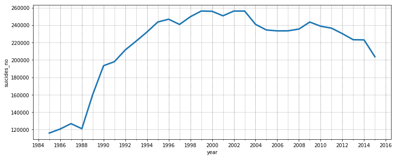

```python
plt.figure(figsize=(13, 5))
ax = sns.lineplot(x="year", y="suicides_no", data=no_for_year, linewidth = 3)
ax.xaxis.set_major_locator(ticker.MultipleLocator(2))
ax.xaxis.set_minor_locator(ticker.MultipleLocator(1))
ax.grid(which='minor',
        color = 'gray',
        linestyle = ':')
ax.grid(which='major',
        color = 'gray',
        linestyle = ':')
```

Как видно из графика в 90-ые годы количество самоубийств начало резко расти, с начала 2000 года можно проследить тренд на понижение. Теперь посмотрим на количество суицидов на 100 тысяч человек в зависимости от года.

```python
tmp = data[['year', 'suicides/100k pop']]
mean_for_year = tmp.groupby(['year']).mean().reset_index()
```

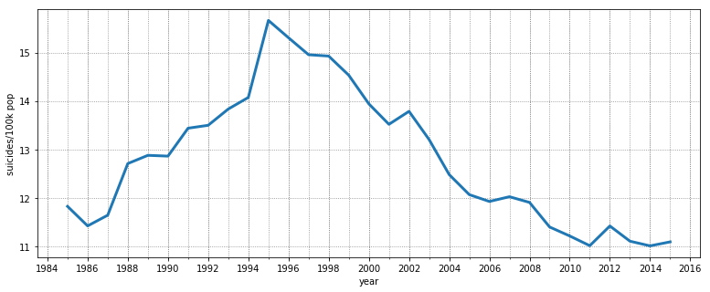

```python
plt.figure(figsize=(13, 5))
ax = sns.lineplot(x="year", y="suicides/100k pop", data=mean_for_year, linewidth = 3)
ax.xaxis.set_major_locator(ticker.MultipleLocator(2))
ax.xaxis.set_minor_locator(ticker.MultipleLocator(1))
ax.grid(which='minor',
        color = 'gray',
        linestyle = ':')
ax.grid(which='major',
        color = 'gray',
        linestyle = ':')
```

На этом графике также виден рост в 90-ые годы. Однако после пика в 1995 году наблюдается довольно активное понижение, которого нет на первом графике. Видимо, это обусловлено численностью населения.

## По странам

```python
by_country= data.groupby(['country'])['suicides/100k pop'].mean().reset_index()
by_country.sort_values('suicides/100k pop',ascending=False, inplace=True)
```

Отсортируем страны в порядке убывания количества суицидов на 100 тысяч человек.

```
Text(0.5,1,'Countries with most suicides')
```

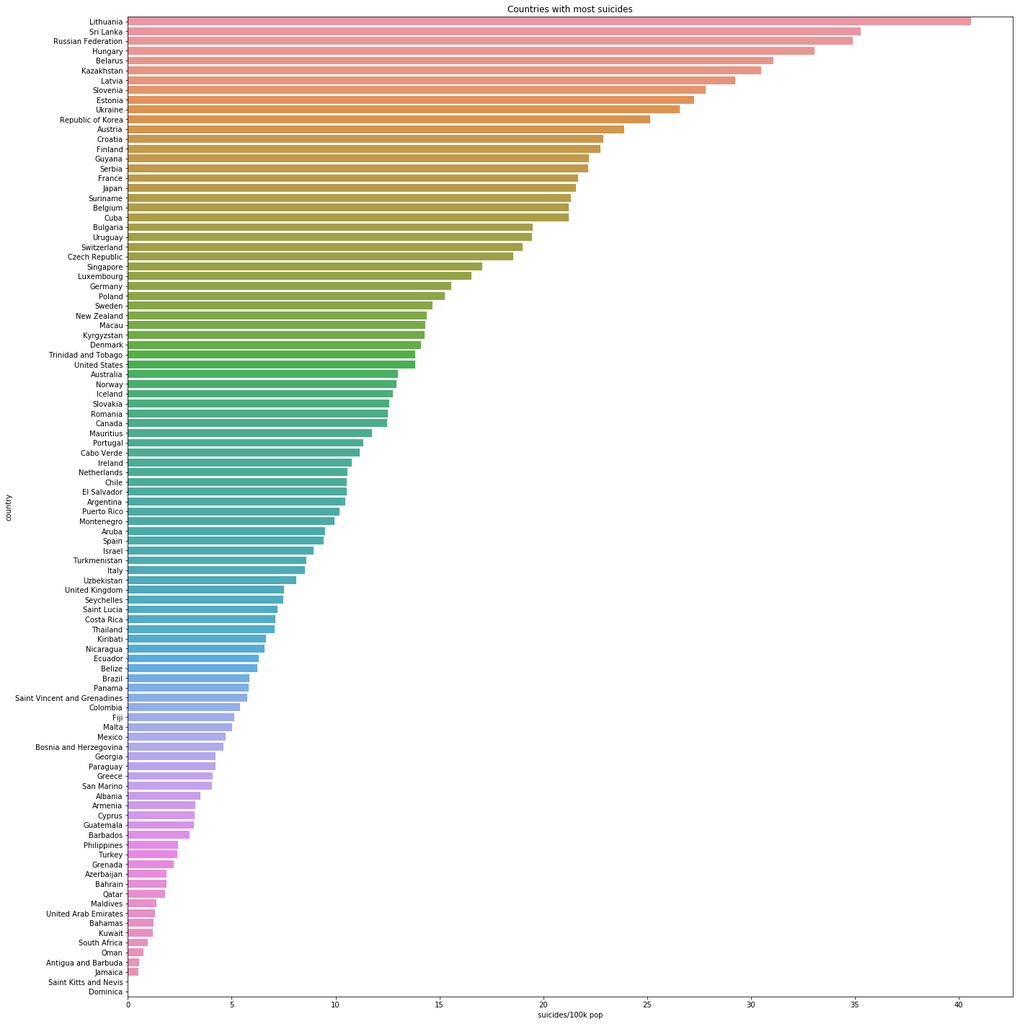

```python
plt.figure(figsize=(22, 25))
sns.barplot(x = "suicides/100k pop", y = "country", data = by_country).set_title("Countries with most suicides")
```

Наверху оказались Литва, Шри-Ланка, Россия, Венгрия и Беларусь. Самое маленькое количество суицидов на 100 тысяч человек у Сент-Китс и Невис, Ямайки, Антигуа и Барбуда, Омана и ЮАР.  
Данных для Доминиканы оказалось слишком мало, всего один год, поэтому ее просто удалим.

```python
data = data[~data.country.isin(['Dominica'])]
```

Теперь изобразим все на карте. Для этого понадобятся трехбуквенные коды стран.  
Добавление кодов:

```python
df = pd.read_csv('codes.csv')
tmp = df.rename(columns={'English short name lower case': 'country', "Alpha-3 code": "code"})
code = tmp[['country', 'code']]
by_country = pd.merge(by_country, code, on=['country'], how='left')
```

```python
indices = list(np.where(by_country['code'].isna()))
print(indices)
```

[output not shown]

```python
by_country['code'][2] = "RUS"
by_country['code'][10] = "KOR"
by_country['code'][70] = "VCT"
by_country['code'][32] = "MAC"
by_country['code'][36] = "USA"
by_country['code'][45] = "CPV"
```

Изобразим "плотность" суицидов на карте:

```python
import plotly.express as px

fig = px.choropleth(by_country, locations="code",
                    color="suicides/100k pop", # lifeExp is a column of gapminder
                    hover_name="country", # column to add to hover information
                    color_continuous_scale=px.colors.sequential.Plasma)

fig.show()
```

[interactive chart not shown]

Помимо нужной величины на карте хорошо видно, как много стран пропущено в датасете. Исключительно ради интереса ниже можно увидеть картинку с количеством самоубийств на 100 тысяч человек во всем мире по данным ВОЗ на 2016 год.

[figure not shown]

```python
from IPython.display import Image
Image("map.png")
```

## Пол

```python
by_sex =data.groupby(['sex'])['suicides/100k pop'].mean().reset_index()
```

Рассмотрим зависимость уровня самоубийств на 100 тысяч человек от пола.

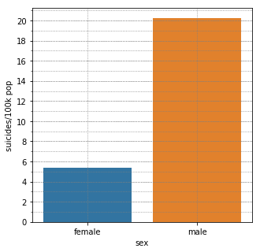

```python
plt.figure(figsize=(5, 5))
p = sns.barplot(x='sex', y='suicides/100k pop', data=by_sex)
p.yaxis.set_major_locator(ticker.MultipleLocator(2))
p.yaxis.set_minor_locator(ticker.MultipleLocator(1))
p.grid(which='major',
        color = 'gray',
        linestyle = ':')
p.grid(which='minor',
        color = 'gray',
        linestyle = ':')
```

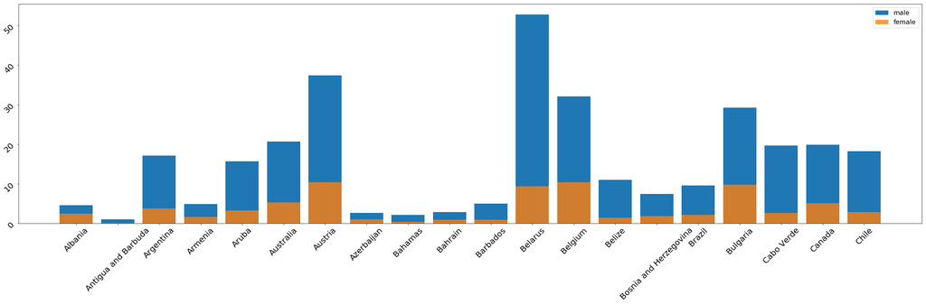

```python
plt.figure(figsize=(40, 10))

female = pd.DataFrame(data.groupby('sex').get_group('female').groupby('country')['suicides/100k pop'].mean())
male = pd.DataFrame(data.groupby('sex').get_group('male').groupby('country')['suicides/100k pop'].mean())
plt.bar(male.index[0:20], male['suicides/100k pop'][0:20])
plt.bar(female.index[0:20], female['suicides/100k pop'][0:20], alpha=0.8)
plt.legend(['male', 'female'], fontsize=16)
plt.xticks(rotation=45, fontsize = 20)
plt.yticks(rotation=45, fontsize = 20)
```

Во всех странах мужчин, совершивших суицид, оказалось больше, чем женщин. Единственной страной-исключением стали Мальдивы.

```python
maldives = data[data.country.isin(['Maldives'])]
maldives_by_sex =maldives.groupby(['sex'])['suicides/100k pop'].mean().reset_index()
```

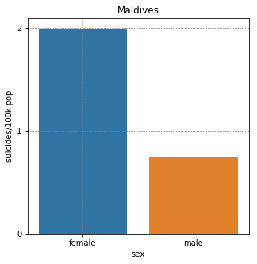

```python
plt.figure(figsize=(5, 5))
p = sns.barplot(x='sex', y='suicides/100k pop', data=maldives_by_sex)
p.set_title('Maldives')
p.yaxis.set_major_locator(ticker.MultipleLocator(1))
p.yaxis.set_minor_locator(ticker.MultipleLocator(1))
p.grid(which='major',
        color = 'gray',
        linestyle = ':')
p.grid(which='minor',
        color = 'gray',
        linestyle = ':')
```

## Возраст

Построим гистограмму количества самоубийств в зависимости от возраста.

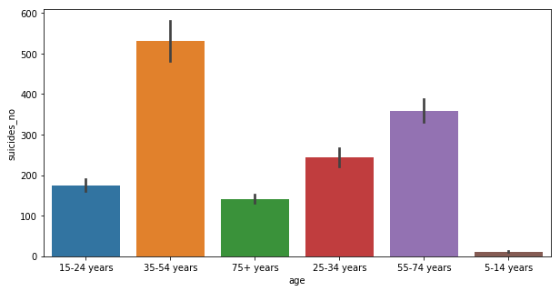

```python
plt.figure(figsize=(10, 5))
age = sns.barplot(x='age', y='suicides_no', data=data, alpha=1)
```

Самый большой показатель оказался у возрастной группы "35-54". Наверное, отчасти это произошло из-за того, что эта группа обхватывает возрастной промежуток в 20 лет.

Теперь посмотрим на то же самое распределение еще и в зависимости от пола:

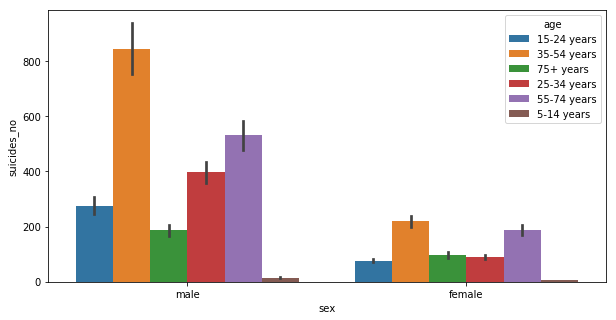

```python
plt.figure(figsize=(10, 5))
age = sns.barplot(x='sex', y='suicides_no', hue='age', data=data)
```

## Другие показатели

Посмотрим на совместные распределения ВВП на душу населения и количества суицидов на 100 тысяч человек:

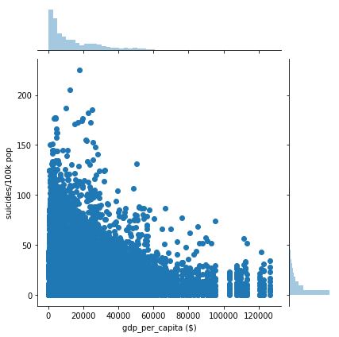

```python
sns.jointplot(x='gdp_per_capita ($)', y='suicides/100k pop', data=data)
plt.show()
```

Все точки сосредоточены в левом нижнем углу.

Теперь посмотрим на ВВП на душу населения и общее количество суицидов:

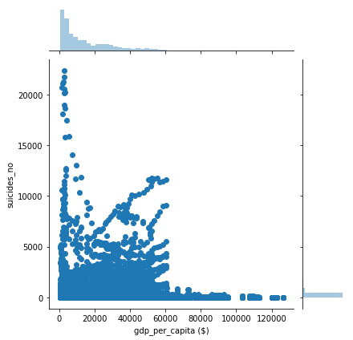

```python
sns.jointplot(x='gdp_per_capita ($)', y='suicides_no', data=data)
plt.show()
```

Здесь можно увидеть несколько прямых.

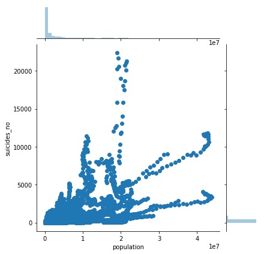

```python
sns.jointplot(x='population', y='suicides_no', data=data)
plt.show()
```

Можно увидеть несколько линейных зависимостей, что довольно логично.